# Исследование объявлений о продаже квартир

```python
# найдем медианную площадь кухни и медианную жилую площадь  и их соотношение

median_kitchen = data['kitchen_area'].median() / data['total_area'].median()

# заполним пропуски kitchen_area, умножив total_area на полученный коэффициент

data['kitchen_area'] = data['kitchen_area'].fillna(data['total_area']*median_kitchen)

data.info()
```

```
<class 'pandas.core.frame.DataFrame'>
Int64Index: 23694 entries, 0 to 23698
Data columns (total 22 columns):
 #   Column                Non-Null Count  Dtype
---  ------                --------------  -----
 0   total_images          23694 non-null  int64
 1   last_price            23694 non-null  float64
 2   total_area            23694 non-null  float64
 3   first_day_exposition  23694 non-null  object
 4   rooms                 23694 non-null  int64
 5   ceiling_height        23694 non-null  float64
 6   floors_total          23694 non-null  float64
 7   living_area           23694 non-null  float64
 8   floor                 23694 non-null  int64
 9   is_apartment          23694 non-null  bool
 10  studio                23694 non-null  bool
 11  open_plan             23694 non-null  bool
 12  kitchen_area          23694 non-null  float64
 13  balcony               23694 non-null  float64
 14  locality_name         23645 non-null  object
 15  airports_nearest      18153 non-null  float64
 16  cityCenters_nearest   18176 non-null  float64
 17  parks_around3000      23694 non-null  float64
 18  parks_nearest         8077 non-null   float64
 19  ponds_around3000      23694 non-null  float64
 20  ponds_nearest         9107 non-null   float64
 21  days_exposition       20513 non-null  float64
dtypes: bool(3), float64(14), int64(3), object(2)
memory usage: 3.7+ MB
```

```python
# переведем тип данных столбца 'first_day_exposition' из строкового в дату и время

data['first_day_exposition'] = pd.to_datetime(data['first_day_exposition'], format ='%Y-%m-%dT%H:%M:%S')

data.info()
```

```
<class 'pandas.core.frame.DataFrame'>
Int64Index: 23694 entries, 0 to 23698
Data columns (total 22 columns):
 #   Column                Non-Null Count  Dtype
---  ------                --------------  -----
 0   total_images          23694 non-null  int64
 1   last_price            23694 non-null  float64
 2   total_area            23694 non-null  float64
 3   first_day_exposition  23694 non-null  datetime64[ns]
 4   rooms                 23694 non-null  int64
 5   ceiling_height        23694 non-null  float64
 6   floors_total          23694 non-null  float64
 7   living_area           23694 non-null  float64
 8   floor                 23694 non-null  int64
 9   is_apartment          23694 non-null  bool
 10  studio                23694 non-null  bool
 11  open_plan             23694 non-null  bool
 12  kitchen_area          23694 non-null  float64
 13  balcony               23694 non-null  float64
 14  locality_name         23645 non-null  object
 15  airports_nearest      18153 non-null  float64
 16  cityCenters_nearest   18176 non-null  float64
 17  parks_around3000      23694 non-null  float64
 18  parks_nearest         8077 non-null   float64
 19  ponds_around3000      23694 non-null  float64
 20  ponds_nearest         9107 non-null   float64
 21  days_exposition       20513 non-null  float64
dtypes: bool(3), datetime64[ns](1), float64(14), int64(3), object(1)
memory usage: 3.7+ MB
```

Поменяли тип данных столбца 'first_day_exposition', чтобы потом правильно обращаться к нему при анализе. Перевели из типа строк в datetime.

```
array([[<AxesSubplot:title={'center':'total_images'}>,
        <AxesSubplot:title={'center':'last_price'}>,
        <AxesSubplot:title={'center':'total_area'}>,
        <AxesSubplot:title={'center':'first_day_exposition'}>],
       [<AxesSubplot:title={'center':'rooms'}>,
        <AxesSubplot:title={'center':'ceiling_height'}>,
        <AxesSubplot:title={'center':'floors_total'}>,
        <AxesSubplot:title={'center':'living_area'}>],
       [<AxesSubplot:title={'center':'floor'}>,
        <AxesSubplot:title={'center':'kitchen_area'}>,
        <AxesSubplot:title={'center':'balcony'}>,
        <AxesSubplot:title={'center':'airports_nearest'}>],
       [<AxesSubplot:title={'center':'cityCenters_nearest'}>,
        <AxesSubplot:title={'center':'parks_around3000'}>,
        <AxesSubplot:title={'center':'parks_nearest'}>,
        <AxesSubplot:title={'center':'ponds_around3000'}>],
       [<AxesSubplot:title={'center':'ponds_nearest'}>,
        <AxesSubplot:title={'center':'days_exposition'}>, <AxesSubplot:>,
        <AxesSubplot:>]], dtype=object)
```

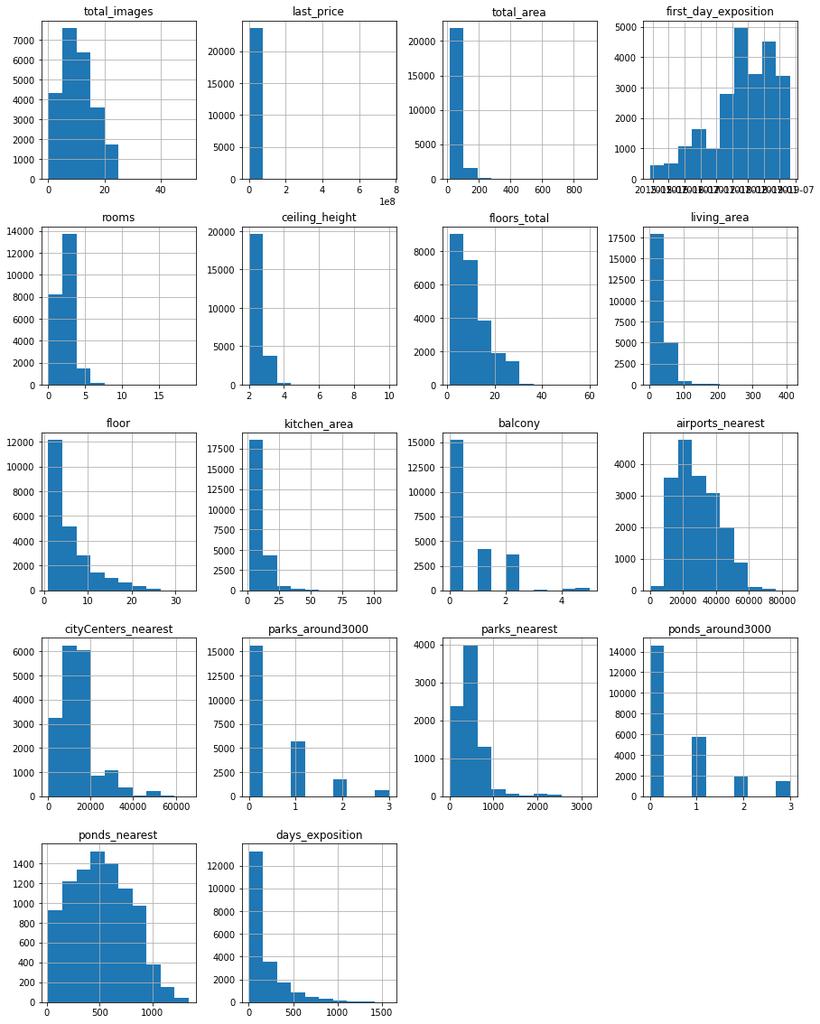

```python
# построим гистограммы для всех числовых столбцов таблицы после внесенных изменений

data.hist(figsize=(15, 20))
```

Теперь удалим данные, которые слишком сильно отличаются от стандартных значений. По графикам выше такие отклонения есть. Отсечем лишнее и заново построим графики зависимостей.

```python
data.info()
```

```
<class 'pandas.core.frame.DataFrame'>
Int64Index: 23694 entries, 0 to 23698
Data columns (total 22 columns):
 #   Column                Non-Null Count  Dtype
---  ------                --------------  -----
 0   total_images          23694 non-null  int64
 1   last_price            23694 non-null  float64
 2   total_area            23694 non-null  float64
 3   first_day_exposition  23694 non-null  datetime64[ns]
 4   rooms                 23694 non-null  int64
 5   ceiling_height        23694 non-null  float64
 6   floors_total          23694 non-null  float64
 7   living_area           23694 non-null  float64
 8   floor                 23694 non-null  int64
 9   is_apartment          23694 non-null  bool
 10  studio                23694 non-null  bool
 11  open_plan             23694 non-null  bool
 12  kitchen_area          23694 non-null  float64
 13  balcony               23694 non-null  float64
 14  locality_name         23645 non-null  object
 15  airports_nearest      18153 non-null  float64
 16  cityCenters_nearest   18176 non-null  float64
 17  parks_around3000      23694 non-null  float64
 18  parks_nearest         8077 non-null   float64
 19  ponds_around3000      23694 non-null  float64
 20  ponds_nearest         9107 non-null   float64
 21  days_exposition       20513 non-null  float64
dtypes: bool(3), datetime64[ns](1), float64(14), int64(3), object(1)
memory usage: 3.7+ MB
```

```python
data_clean = data.query('total_area < 150')
data_clean = data_clean.query('living_area < 100')
data_clean = data_clean.query('living_area > 15')

data_clean.info()
```

```
<class 'pandas.core.frame.DataFrame'>
Int64Index: 22013 entries, 0 to 23697
Data columns (total 22 columns):
 #   Column                Non-Null Count  Dtype
---  ------                --------------  -----
 0   total_images          22013 non-null  int64
 1   last_price            22013 non-null  float64
 2   total_area            22013 non-null  float64
 3   first_day_exposition  22013 non-null  datetime64[ns]
 4   rooms                 22013 non-null  int64
 5   ceiling_height        22013 non-null  float64
 6   floors_total          22013 non-null  float64
 7   living_area           22013 non-null  float64
 8   floor                 22013 non-null  int64
 9   is_apartment          22013 non-null  bool
 10  studio                22013 non-null  bool
 11  open_plan             22013 non-null  bool
 12  kitchen_area          22013 non-null  float64
 13  balcony               22013 non-null  float64
 14  locality_name         21967 non-null  object
 15  airports_nearest      16836 non-null  float64
 16  cityCenters_nearest   16856 non-null  float64
 17  parks_around3000      22013 non-null  float64
 18  parks_nearest         7414 non-null   float64
 19  ponds_around3000      22013 non-null  float64
 20  ponds_nearest         8333 non-null   float64
 21  days_exposition       19085 non-null  float64
dtypes: bool(3), datetime64[ns](1), float64(14), int64(3), object(1)
memory usage: 3.4+ MB
```

```
array([[<AxesSubplot:title={'center':'total_images'}>,
        <AxesSubplot:title={'center':'last_price'}>,
        <AxesSubplot:title={'center':'total_area'}>,
        <AxesSubplot:title={'center':'first_day_exposition'}>],
       [<AxesSubplot:title={'center':'rooms'}>,
        <AxesSubplot:title={'center':'ceiling_height'}>,
        <AxesSubplot:title={'center':'floors_total'}>,
        <AxesSubplot:title={'center':'living_area'}>],
       [<AxesSubplot:title={'center':'floor'}>,
        <AxesSubplot:title={'center':'kitchen_area'}>,
        <AxesSubplot:title={'center':'balcony'}>,
        <AxesSubplot:title={'center':'airports_nearest'}>],
       [<AxesSubplot:title={'center':'cityCenters_nearest'}>,
        <AxesSubplot:title={'center':'parks_around3000'}>,
        <AxesSubplot:title={'center':'parks_nearest'}>,
        <AxesSubplot:title={'center':'ponds_around3000'}>],
       [<AxesSubplot:title={'center':'ponds_nearest'}>,
        <AxesSubplot:title={'center':'days_exposition'}>, <AxesSubplot:>,
        <AxesSubplot:>]], dtype=object)
```

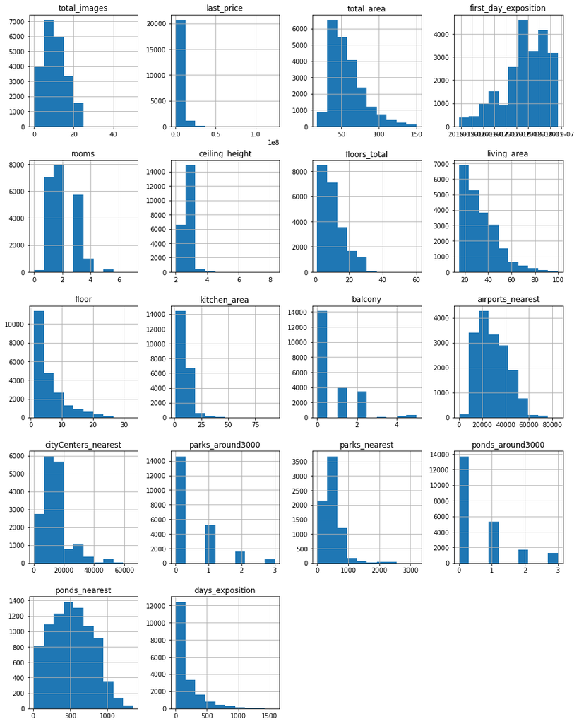

```python
data_clean.hist(figsize=(15, 20))
```

```python
# посчитаем долю оставшихся данных от изачальных

data_clean.shape[0]/data.shape[0]
```

```
0.9290537688866379
```

Очищенные данные составили 92 процентa от изначальных.

### Посчитайте и добавьте в таблицу новые столбцы

```python
# добавим новый столбец Цена квадратного метра

data_clean['one_meter_price'] = data_clean['last_price'] / data_clean['living_area']

# проверим данные

data_clean.info()
```

```
<class 'pandas.core.frame.DataFrame'>
Int64Index: 22013 entries, 0 to 23697
Data columns (total 23 columns):
 #   Column                Non-Null Count  Dtype
---  ------                --------------  -----
 0   total_images          22013 non-null  int64
 1   last_price            22013 non-null  float64
 2   total_area            22013 non-null  float64
 3   first_day_exposition  22013 non-null  datetime64[ns]
 4   rooms                 22013 non-null  int64
 5   ceiling_height        22013 non-null  float64
 6   floors_total          22013 non-null  float64
 7   living_area           22013 non-null  float64
 8   floor                 22013 non-null  int64
 9   is_apartment          22013 non-null  bool
 10  studio                22013 non-null  bool
 11  open_plan             22013 non-null  bool
 12  kitchen_area          22013 non-null  float64
 13  balcony               22013 non-null  float64
 14  locality_name         21967 non-null  object
 15  airports_nearest      16836 non-null  float64
 16  cityCenters_nearest   16856 non-null  float64
 17  parks_around3000      22013 non-null  float64
 18  parks_nearest         7414 non-null   float64
 19  ponds_around3000      22013 non-null  float64
 20  ponds_nearest         8333 non-null   float64
 21  days_exposition       19085 non-null  float64
 22  one_meter_price       22013 non-null  float64
dtypes: bool(3), datetime64[ns](1), float64(15), int64(3), object(1)
memory usage: 3.6+ MB
```

```python
# добавим новые столбцы месяц и год публикации объявления

data_clean['month_exposition'] = pd.DatetimeIndex(data_clean['first_day_exposition']).month
data_clean['year_exposition'] =  pd.DatetimeIndex(data_clean['first_day_exposition']).year

# проверим данные

data_clean.info()
```

```
<class 'pandas.core.frame.DataFrame'>
Int64Index: 22013 entries, 0 to 23697
Data columns (total 25 columns):
 #   Column                Non-Null Count  Dtype
---  ------                --------------  -----
 0   total_images          22013 non-null  int64
 1   last_price            22013 non-null  float64
 2   total_area            22013 non-null  float64
 3   first_day_exposition  22013 non-null  datetime64[ns]
 4   rooms                 22013 non-null  int64
 5   ceiling_height        22013 non-null  float64
 6   floors_total          22013 non-null  float64
 7   living_area           22013 non-null  float64
 8   floor                 22013 non-null  int64
 9   is_apartment          22013 non-null  bool
```

[output cut: 17 more lines]

```python
# добавим новый столбец дня публикации объявления (0- пн, 1- вт и т.д)

data_clean['day_exposition'] = data_clean['first_day_exposition'].dt.weekday
```

```python
# проверим вывод данных

data_clean.head()
```

|  | total_images | last_price | total_area | first_day_exposition | rooms | ceiling_height | floors_total | living_area | floor | is_apartment | ... | cityCenters_nearest | parks_around3000 | parks_nearest | ponds_around3000 | ponds_nearest | days_exposition | one_meter_price | month_exposition | year_exposition | day_exposition |
| --- | --- | --- | --- | --- | --- | --- | --- | --- | --- | --- | --- | --- | --- | --- | --- | --- | --- | --- | --- | --- | --- |
| 0 | 20 | 13000000.0 | 108.0 | 2019-03-07 | 3 | 2.70 | 16.0 | 51.000000 | 8 | True | ... | 16028.0 | 1.0 | 482.0 | 2.0 | 755.0 | NaN | 254901.960784 | 3 | 2019 | 3 |
| 1 | 7 | 3350000.0 | 40.4 | 2018-12-04 | 1 | 2.65 | 11.0 | 18.600000 | 1 | True | ... | 18603.0 | 0.0 | NaN | 0.0 | NaN | 81.0 | 180107.526882 | 12 | 2018 | 1 |
| 2 | 10 | 5196000.0 | 56.0 | 2015-08-20 | 2 | 2.65 | 5.0 | 34.300000 | 4 | True | ... | 13933.0 | 1.0 | 90.0 | 2.0 | 574.0 | 558.0 | 151486.880466 | 8 | 2015 | 3 |
| 4 | 2 | 10000000.0 | 100.0 | 2018-06-19 | 2 | 3.03 | 14.0 | 32.000000 | 13 | True | ... | 8098.0 | 2.0 | 112.0 | 1.0 | 48.0 | 121.0 | 312500.000000 | 6 | 2018 | 1 |
| 7 | 5 | 7915000.0 | 71.6 | 2019-04-18 | 2 | 2.65 | 24.0 | 41.307692 | 22 | True | ... | 11634.0 | 0.0 | NaN | 0.0 | NaN | NaN | 191610.800745 | 4 | 2019 | 3 |

5 rows × 26 columns

```python
# сделаем функцию для категоризации этаже - первый, последний или другой

def make_floor_type(row):
    for i in range(len(data.index)):
        if row['floor'] == 1:
            return 'первый'
        elif row['floor'] == row['floors_total']:
            return 'последний'
        else:
            return 'другой'


# сделаем новый столбец с категорией этажа

data_clean['floor_type'] = data_clean.apply(make_floor_type, axis=1)

data_clean.info()
```

```
<class 'pandas.core.frame.DataFrame'>
Int64Index: 22013 entries, 0 to 23697
Data columns (total 27 columns):
 #   Column                Non-Null Count  Dtype
---  ------                --------------  -----
 0   total_images          22013 non-null  int64
 1   last_price            22013 non-null  float64
 2   total_area            22013 non-null  float64
 3   first_day_exposition  22013 non-null  datetime64[ns]
 4   rooms                 22013 non-null  int64
 5   ceiling_height        22013 non-null  float64
 6   floors_total          22013 non-null  float64
 7   living_area           22013 non-null  float64
 8   floor                 22013 non-null  int64
 9   is_apartment          22013 non-null  bool
```

[output cut: 19 more lines]

```python
# проверим вывод данных

data_clean.head()
```

|  | total_images | last_price | total_area | first_day_exposition | rooms | ceiling_height | floors_total | living_area | floor | is_apartment | ... | parks_around3000 | parks_nearest | ponds_around3000 | ponds_nearest | days_exposition | one_meter_price | month_exposition | year_exposition | day_exposition | floor_type |
| --- | --- | --- | --- | --- | --- | --- | --- | --- | --- | --- | --- | --- | --- | --- | --- | --- | --- | --- | --- | --- | --- |
| 0 | 20 | 13000000.0 | 108.0 | 2019-03-07 | 3 | 2.70 | 16.0 | 51.000000 | 8 | True | ... | 1.0 | 482.0 | 2.0 | 755.0 | NaN | 254901.960784 | 3 | 2019 | 3 | другой |
| 1 | 7 | 3350000.0 | 40.4 | 2018-12-04 | 1 | 2.65 | 11.0 | 18.600000 | 1 | True | ... | 0.0 | NaN | 0.0 | NaN | 81.0 | 180107.526882 | 12 | 2018 | 1 | первый |
| 2 | 10 | 5196000.0 | 56.0 | 2015-08-20 | 2 | 2.65 | 5.0 | 34.300000 | 4 | True | ... | 1.0 | 90.0 | 2.0 | 574.0 | 558.0 | 151486.880466 | 8 | 2015 | 3 | другой |
| 4 | 2 | 10000000.0 | 100.0 | 2018-06-19 | 2 | 3.03 | 14.0 | 32.000000 | 13 | True | ... | 2.0 | 112.0 | 1.0 | 48.0 | 121.0 | 312500.000000 | 6 | 2018 | 1 | другой |
| 7 | 5 | 7915000.0 | 71.6 | 2019-04-18 | 2 | 2.65 | 24.0 | 41.307692 | 22 | True | ... | 0.0 | NaN | 0.0 | NaN | NaN | 191610.800745 | 4 | 2019 | 3 | другой |

5 rows × 27 columns

```python
# добавим столбец с расстоянием до центра города в километрах. Переведем значение из метров в км, округлим до целых значений

data_clean['cityCenters_nearest_km'] = round(data_clean['cityCenters_nearest'] / 1000)

data_clean.info()
```

```
<class 'pandas.core.frame.DataFrame'>
Int64Index: 22013 entries, 0 to 23697
Data columns (total 28 columns):
 #   Column                  Non-Null Count  Dtype
---  ------                  --------------  -----
 0   total_images            22013 non-null  int64
 1   last_price              22013 non-null  float64
 2   total_area              22013 non-null  float64
 3   first_day_exposition    22013 non-null  datetime64[ns]
 4   rooms                   22013 non-null  int64
 5   ceiling_height          22013 non-null  float64
 6   floors_total            22013 non-null  float64
 7   living_area             22013 non-null  float64
 8   floor                   22013 non-null  int64
 9   is_apartment            22013 non-null  bool
```

[output cut: 20 more lines]

```python
# проверим вывод данных

data_clean.head()
```

|  | total_images | last_price | total_area | first_day_exposition | rooms | ceiling_height | floors_total | living_area | floor | is_apartment | ... | parks_nearest | ponds_around3000 | ponds_nearest | days_exposition | one_meter_price | month_exposition | year_exposition | day_exposition | floor_type | cityCenters_nearest_km |
| --- | --- | --- | --- | --- | --- | --- | --- | --- | --- | --- | --- | --- | --- | --- | --- | --- | --- | --- | --- | --- | --- |
| 0 | 20 | 13000000.0 | 108.0 | 2019-03-07 | 3 | 2.70 | 16.0 | 51.000000 | 8 | True | ... | 482.0 | 2.0 | 755.0 | NaN | 254901.960784 | 3 | 2019 | 3 | другой | 16.0 |
| 1 | 7 | 3350000.0 | 40.4 | 2018-12-04 | 1 | 2.65 | 11.0 | 18.600000 | 1 | True | ... | NaN | 0.0 | NaN | 81.0 | 180107.526882 | 12 | 2018 | 1 | первый | 19.0 |
| 2 | 10 | 5196000.0 | 56.0 | 2015-08-20 | 2 | 2.65 | 5.0 | 34.300000 | 4 | True | ... | 90.0 | 2.0 | 574.0 | 558.0 | 151486.880466 | 8 | 2015 | 3 | другой | 14.0 |
| 4 | 2 | 10000000.0 | 100.0 | 2018-06-19 | 2 | 3.03 | 14.0 | 32.000000 | 13 | True | ... | 112.0 | 1.0 | 48.0 | 121.0 | 312500.000000 | 6 | 2018 | 1 | другой | 8.0 |
| 7 | 5 | 7915000.0 | 71.6 | 2019-04-18 | 2 | 2.65 | 24.0 | 41.307692 | 22 | True | ... | NaN | 0.0 | NaN | NaN | 191610.800745 | 4 | 2019 | 3 | другой | 12.0 |

5 rows × 28 columns

**Вывод:**

На данном шаге добавили столбцы:

- one_meter_price Цена за 1 кв. метр
- month_exposition Месяц размещения объявления
- year_exposition Год размещения объявления
- day_exposition День размещения объявления (0 - пн, 1 - вт и тд)
- floor_type Тип этажа ( первый, последний, другие)
- cityCenters_nearest_km Расстояние до центра города в км